# Store 20974

## Statistical Analysis for store 20974

To begin with, splitting the dataset into training set and testing set is a must. By selecting the 8.5:1.5 ratio of splitting the original dataset, we can fit the model and test to see the accuracy for further prediction.

```r
train_20974 <- window(ts_20974, end = c(03,85), frequency = 7)
test_20974 <- window(ts_20974, start = c(03,86))
```

### Holt-Winters Method

```r
## Initial Holt-Winters with exponential smoothing
HW_20974 <- HoltWinters(ts_20974, beta = FALSE)
HW_20974
```

```
Holt-Winters exponential smoothing without trend and with additive seasonal component.

Call:
HoltWinters(x = ts_20974, beta = FALSE)

Smoothing parameters:
 alpha: 0.3056737
 beta : FALSE
 gamma: 0.3984021

Coefficients:
         [,1]
a  209.721979
s1  45.518637
s2  67.782061
s3  82.327311
s4 -16.762841
s5 -32.103088
s6  -9.159774
s7  48.156004
```

```r
## Initial ETS model with automatic fitting
ETS_20974 <- ets(ts_20974, model = 'ZZZ')
ETS_20974
```

```
ETS(A,Ad,A)

Call:
 ets(y = ts_20974, model = "ZZZ")

  Smoothing parameters:
    alpha = 0.1309
    beta  = 0.0053
    gamma = 5e-04
    phi   = 0.9254

  Initial states:
    l = -20.3284
    b = 21.8993
    s = -16.0598 14.9368 28.8042 12.3617 12.9386 2.8771
           -55.8587

  sigma:  50.4337

     AIC     AICc      BIC
1177.315 1181.865 1210.378
```

We are going to apply the model onto the training and testing set to do the forecasting.

#### Forecasting on Training Set

```r
#Holt-Winters
train_HW_20974 <- HoltWinters(train_20974, beta = FALSE)
forecast_HW_20974  <- forecast(train_HW_20974, h = 14)
#ets
train_ets_20974 <- ets(train_20974, model = 'ZZZ')
forecast_ets_20974  <- forecast(train_ets_20974, h = 14)

plot(train_HW_20974, main="Holt-Winters vs. ETS (A,N,A) on training set",
     xlab="Time",
     ylab="Lettuce Demand", lty = 1, col = "black", frame.plot = FALSE)
lines(fitted(train_ets_20974), col = "Blue", lty = 2)
legend("bottom", legend=c("Actual","Holt-Winter", "ETS"), col=c("black", "red", "blue"), box.lty=0, lty=c(1,1,2), cex=0.8)
```

[output not shown]

```r
## Accuracy Comparison
acc_ets_HW_20974 <- rbind(forecast::accuracy(forecast_HW_20974,
                                       test_20974),
                        forecast::accuracy(forecast_ets_20974,
                                 test_20974))

acc_ets_HW_20974_df <- data.frame(acc_ets_HW_20974,
                                row.names = c('HW_on_Train', 'HW_on_Test',
                                              'ETS_on_Train', 'ETS_on_Test'))

acc_ets_HW_20974_df %>%  kable(caption = "Accuracy: Holt-Winter vs. ETS",
                                  align = 'c') %>%
  kable_styling() %>%
  pack_rows("Holt-Winters", 1, 2) %>%
  pack_rows("ETS", 3, 4)
```

Accuracy: Holt-Winter vs. ETS

|  | ME | RMSE | MAE | MPE | MAPE | MASE | ACF1 | Theil.s.U |
| --- | --- | --- | --- | --- | --- | --- | --- | --- |
| **Holt-Winters** |  |  |  |  |  |  |  |  |
| HW_on_Train | 6.299455 | 60.70995 | 48.01069 | -15.063034 | 39.16326 | 0.8384643 | 0.1939396 | NA |
| HW_on_Test | 39.013965 | 62.57655 | 40.75211 | 15.437589 | 16.40232 | 0.7116995 | -0.2349543 | 0.9700623 |
| **ETS** |  |  |  |  |  |  |  |  |
| ETS_on_Train | -6.039023 | 45.29688 | 37.35705 | -Inf | Inf | 0.6524078 | 0.2227129 | NA |
| ETS_on_Test | 28.172924 | 58.65815 | 35.38409 | 9.464418 | 13.72559 | 0.6179518 | -0.2645748 | 0.8704160 |

*Table 2.1:* *This table provides the comparison information for store 20974.*

From the table above, since the ETS model has the lowest RMSE value, we are going to select ETS model.

#### Final ETS Model

```r
final_ets_20974 <- forecast(ETS_20974, h = 14)
final_ets_20974_1 <- as.data.frame(forecast(ETS_20974, h = 14))
final_ets_20974_df <- data.frame(final_ets_20974_1$`Point Forecast`,
                     row.names = c('16/06/15', '17/06/15',
                                   '18/06/15', '19/06/15',
                                   '20/06/15', '21/06/15',
                                   '22/06/15','23/06/15',
                                   '24/06/15', '25/06/15',
                                   '26/06/15', '27/06/15',
                                   '28/06/15', '29/06/15'))
final_ets_20974_df %>%
  kable(caption = "14 Day ETS Forecast for Store 20974", align = 'c', col.names = 'Lettuce Demand') %>%
  kable_styling(full_width = F)
```

14 Day ETS Forecast for Store 20974

|  | Lettuce Demand |
| --- | --- |
| 16/06/15 | 237.9924 |
| 17/06/15 | 254.8547 |
| 18/06/15 | 241.4441 |
| 19/06/15 | 210.8600 |
| 20/06/15 | 171.3848 |
| 21/06/15 | 230.4058 |
| 22/06/15 | 240.8507 |
| 23/06/15 | 240.5104 |
| 24/06/15 | 257.1850 |
| 25/06/15 | 243.6006 |
| 26/06/15 | 212.8556 |
| 27/06/15 | 173.2316 |
| 28/06/15 | 232.1149 |
| 29/06/15 | 242.4323 |

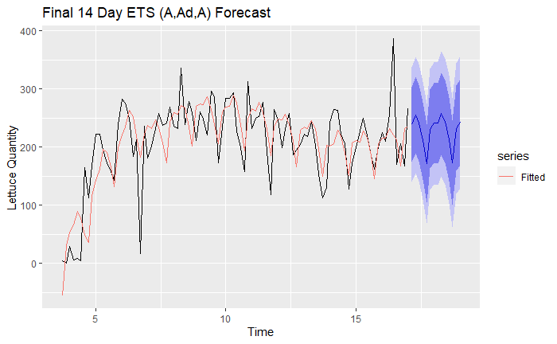

```r
autoplot(final_ets_20974,
         main = 'Final 14 Day ETS (A,Ad,A) Forecast',
         ylab = 'Lettuce Quantity',
         xlab = 'Time') +
  autolayer(fitted(final_ets_20974),
            series = 'Fitted', na.rm=TRUE)
```

*Table 2.2:* *This table provides the ETS forecasting fitted value for store 20974.*  
*Figure 2.2:* *This figure provides the forecasting plot for store 20974.*

### ARIMA Forecast Models

I then develop the ARIMA model for store 20974 to forecast the demand of lettuce. The ARIMA model will then be compared with the final ETS model above to determine which is the most accuracy model and to do the further forecasting based on the accuracy of the model.

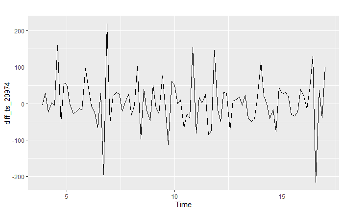

```r
#ts diff
diff_ts_20974 <- diff(ts_20974, differences = 1)
autoplot(diff_ts_20974)
```

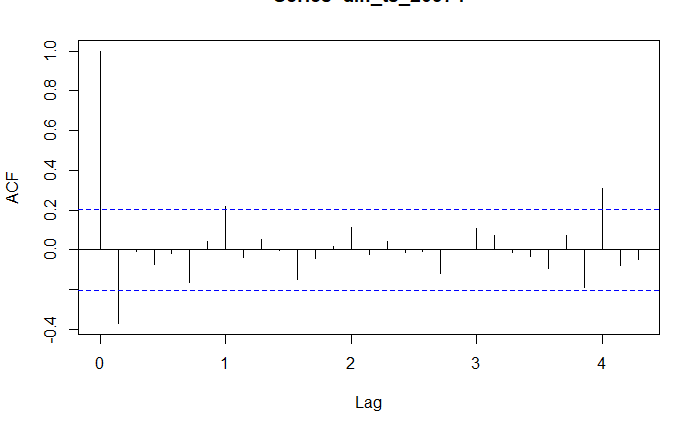

```r
acf(diff_ts_20974, lag.max = 30)
```

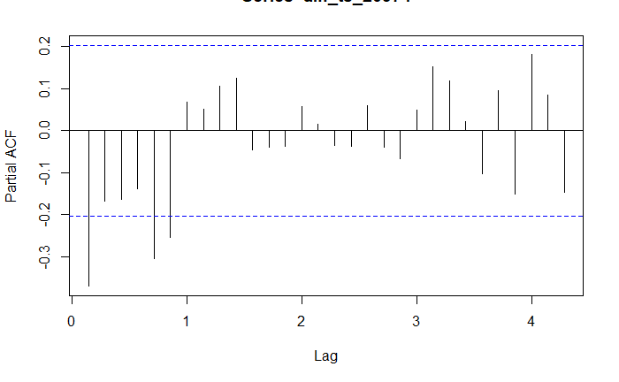

```r
pacf(diff_ts_20974, lag.max = 30)
```

```r
adf.test(diff_ts_20974)
```

```
p-value smaller than printed p-value
```

```
    Augmented Dickey-Fuller Test

data:  diff_ts_20974
Dickey-Fuller = -7.6175, Lag order = 4, p-value = 0.01
alternative hypothesis: stationary
```

```r
kpss.test(diff_ts_20974, null = 'Trend')
```

```
p-value greater than printed p-value
```

```
    KPSS Test for Trend Stationarity

data:  diff_ts_20974
KPSS Trend = 0.041817, Truncation lag parameter = 3, p-value = 0.1
```

```r
pp.test(diff_ts_20974)
```

```
p-value smaller than printed p-value
```

```
    Phillips-Perron Unit Root Test

data:  diff_ts_20974
Dickey-Fuller Z(alpha) = -112.32, Truncation lag parameter = 3, p-value = 0.01
alternative hypothesis: stationary
```

```r
ndiffs(diff_ts_20974)
```

```
[1] 0
```

```r
nsdiffs(diff_ts_20974)
```

```
[1] 0
```

*Figure 2.3:* *This figure provides the ACF and PACF information for store 20974*

As the p-value for Dickey-Fuller and Phillips-Perron Unit Root Test are smaller than 0.01, and the p-value for KPSS Test is larger than 0.01, the result above indicates stationary for the time series dataset. The ndiffs test return the value 0 and the nsdiffs test return the value of 0 after taking one difference, which indicates seasonal stationary.

```r
auto.arima(ts_20974, d=1, trace = TRUE, ic = 'aic', approximation = FALSE)
```

```
 ARIMA(2,1,2)(1,0,1)[7] with drift         : 1018.605
 ARIMA(0,1,0)           with drift         : 1045.39
 ARIMA(1,1,0)(1,0,0)[7] with drift         : 1024.992
 ARIMA(0,1,1)(0,0,1)[7] with drift         : 1017.885
 ARIMA(0,1,0)                              : 1043.563
 ARIMA(0,1,1)           with drift         : 1025.103
 ARIMA(0,1,1)(1,0,1)[7] with drift         : 1014.62
 ARIMA(0,1,1)(1,0,0)[7] with drift         : 1016.259
 ARIMA(0,1,1)(2,0,1)[7] with drift         : 1016.393
 ARIMA(0,1,1)(1,0,2)[7] with drift         : 1016.195
 ARIMA(0,1,1)(0,0,2)[7] with drift         : 1018.836
 ARIMA(0,1,1)(2,0,0)[7] with drift         : 1018.027
 ARIMA(0,1,1)(2,0,2)[7] with drift         : Inf
 ARIMA(0,1,0)(1,0,1)[7] with drift         : 1039.26
 ARIMA(1,1,1)(1,0,1)[7] with drift         : 1015.953
 ARIMA(0,1,2)(1,0,1)[7] with drift         : 1016.157
 ARIMA(1,1,0)(1,0,1)[7] with drift         : Inf
 ARIMA(1,1,2)(1,0,1)[7] with drift         : 1017.499
 ARIMA(0,1,1)(1,0,1)[7]                    : 1013.163
 ARIMA(0,1,1)(0,0,1)[7]                    : 1016.932
 ARIMA(0,1,1)(1,0,0)[7]                    : 1015.283
 ARIMA(0,1,1)(2,0,1)[7]                    : 1014.942
 ARIMA(0,1,1)(1,0,2)[7]                    : 1014.745
 ARIMA(0,1,1)                              : 1024.207
 ARIMA(0,1,1)(0,0,2)[7]                    : 1017.873
 ARIMA(0,1,1)(2,0,0)[7]                    : 1017.045
 ARIMA(0,1,1)(2,0,2)[7]                    : Inf
 ARIMA(0,1,0)(1,0,1)[7]                    : 1037.324
 ARIMA(1,1,1)(1,0,1)[7]                    : 1014.666
 ARIMA(0,1,2)(1,0,1)[7]                    : 1014.821
 ARIMA(1,1,0)(1,0,1)[7]                    : Inf
 ARIMA(1,1,2)(1,0,1)[7]                    : 1016.224

 Best model: ARIMA(0,1,1)(1,0,1)[7]

Series: ts_20974
ARIMA(0,1,1)(1,0,1)[7]

Coefficients:
          ma1    sar1     sma1
      -0.6158  0.9185  -0.7350
s.e.   0.0950  0.0759   0.1414

sigma^2 estimated as 2891:  log likelihood=-502.58
AIC=1013.16   AICc=1013.62   BIC=1023.29
```

#### ARIMA Functions Selected

```r
arima1_20974 <- Arima(ts_20974, order = c(0, 1 ,1), seasonal = list(order = c(1, 0, 0), period = 7))
arima2_20974 <- Arima(ts_20974, order = c(0, 1 ,1), seasonal = list(order = c(1, 0, 1), period = 7))
arima3_20974 <- Arima(ts_20974, order = c(0, 1 ,1), seasonal = list(order = c(0, 0, 1), period = 7))
arima4_20974 <- Arima(ts_20974, order = c(0, 1 ,1), seasonal = list(order = c(1, 0, 2), period = 7))
arima5_20974 <- Arima(ts_20974, order = c(0, 1 ,1), seasonal = list(order = c(0, 0, 2), period = 7))
```

The forecast function is used on each ARIMA model and used with a 14 period forecast.

```r
# 14 day ARIMA forecast
forecast_arima1_20974 <- forecast(arima1_20974, h = 14)
forecast_arima2_20974 <- forecast(arima2_20974, h = 14)
forecast_arima3_20974 <- forecast(arima3_20974, h = 14)
forecast_arima4_20974 <- forecast(arima4_20974, h = 14)
forecast_arima5_20974 <- forecast(arima5_20974, h = 14)
```

```r
accuracy_arima_20974 <- rbind(forecast::accuracy(forecast_arima1_20974), forecast::accuracy(forecast_arima2_20974), forecast::accuracy(forecast_arima3_20974),
           forecast::accuracy(forecast_arima4_20974), forecast::accuracy(forecast_arima5_20974))

accuracy_arima_20974_k <- data.frame(accuracy_arima_20974,
                                     row.names = c('ARIMA(0,1,1)(1,0,0)',
                                                   'ARIMA(0,1,1)(1,0,1)',
                                                   'ARIMA(0,1,1)(0,0,1)',
                                                   'ARIMA(0,1,1)(1,0,2)',
                                                   'ARIMA(0,1,1)(0,0,2)'))
accuracy_arima_20974_k %>%  kable(caption = "Accuracy of ARIMA Model", align = 'c') %>%  kable_styling(full_width = F)
```

Accuracy of ARIMA Model

|  | ME | RMSE | MAE | MPE | MAPE | MASE | ACF1 |
| --- | --- | --- | --- | --- | --- | --- | --- |
| ARIMA(0,1,1)(1,0,0) | 4.0638680 | 54.25604 | 40.27817 | -Inf | Inf | 0.7506856 | 0.0345157 |
| ARIMA(0,1,1)(1,0,1) | 0.6072347 | 52.60846 | 38.65742 | -Inf | Inf | 0.7204788 | 0.0323683 |
| ARIMA(0,1,1)(0,0,1) | 4.9553108 | 54.80772 | 41.10300 | -Inf | Inf | 0.7660584 | 0.0401401 |
| ARIMA(0,1,1)(1,0,2) | 0.7580291 | 52.55540 | 38.48333 | -Inf | Inf | 0.7172343 | 0.0277364 |
| ARIMA(0,1,1)(0,0,2) | 4.3085419 | 54.45107 | 40.42558 | -Inf | Inf | 0.7534331 | 0.0368112 |

*Table 2.3:* *This table provides the model pool information for store 20974.*

Based on the table above, we can see that the model ARIMA(0,1,1)(1,0,2) has the lowest RMSE, then comes with ARIMA(0,1,1)(1,0,1).

```r
#Training arima
training_arima4_20974 <- arima(train_20974,
                                    order = c(0, 1 ,1),
                                    seasonal = list(order = c(1, 0, 2),
                                                    period = 7))
training_arima2_20974 <- arima(train_20974,
                                    order = c(0, 1 ,1),
                                    seasonal = list(order = c(1, 0, 1),
                                                    period = 7))

## Forecast using the training set
forecast_arima2_20974 <- forecast(training_arima2_20974, h = 19)
forecast_arima4_20974 <- forecast(training_arima4_20974, h = 19)
```

```r
accuracy_final_arima_20974 <- rbind(accuracy(forecast_arima2_20974,
                                            test_20974),
                              accuracy(forecast_arima4_20974,
                                       test_20974))

accuracy_final_arima_20974_k <- data.frame(accuracy_final_arima_20974,
                                          row.names = c('Train_2', 'Test_2',
                                                        'Train_4', 'Test_4'))

accuracy_final_arima_20974_k %>%  kable(caption = "Accuracy of ARIMA Models", align = 'c') %>%  kable_styling(full_width = F) %>%
  pack_rows("ARIMA(0,1,1)(1,0,1)", 1, 2) %>%
  pack_rows("ARIMA(0,1,1)(1,0,2)", 3, 4)
```

Accuracy of ARIMA Models

|  | ME | RMSE | MAE | MPE | MAPE | MASE | ACF1 | Theil.s.U |
| --- | --- | --- | --- | --- | --- | --- | --- | --- |
| **ARIMA(0,1,1)(1,0,1)** |  |  |  |  |  |  |  |  |
| Train_2 | -1.0140812 | 51.66145 | 38.80457 | -Inf | Inf | 0.6776874 | 0.0375242 | NA |
| Test_2 | 36.3463517 | 60.67004 | 40.40236 | 13.25929 | 15.67269 | 0.7055915 | -0.2403432 | 0.9058967 |
| **ARIMA(0,1,1)(1,0,2)** |  |  |  |  |  |  |  |  |
| Train_4 | -0.7632822 | 51.39960 | 38.75011 | -Inf | Inf | 0.6767364 | 0.0338104 | NA |
| Test_4 | 30.2976030 | 58.22247 | 37.72631 | 10.26118 | 14.65342 | 0.6588566 | -0.2346615 | 0.8543104 |

*Table 2.4:* *This table provides the model comparison information for store 20974.*

#### Final ARIMA Model

```r
## Best model plotted
best_arima_20974 <- arima(ts_20974,
                               order = c(0, 1 ,1),
                               seasonal = list(order = c(1, 0, 2),
                                               period = 7))
forecast_best_arima_20974 <- forecast(best_arima_20974, h = 14)
forecast_best_arima_20974_1 <- as.data.frame(forecast_best_arima_20974)

forecast_best_arima_20974_df <- data.frame(forecast_best_arima_20974_1$`Point Forecast`,
                                               row.names = c('16/06/15', '17/06/15', '18/06/15',
                                                             '19/06/15', '20/06/15', '21/06/15',
                                                             '22/06/15', '23/06/15', '24/06/15',
                                                             '25/06/15', '26/06/15', '27/06/15',
                                                             '28/06/15', '29/06/15'))
forecast_best_arima_20974_df %>%  kable(caption = "Final 14 Day ARIMA Forecast", align = 'c',  col.names = 'Lettuce Demand') %>%  kable_styling(full_width = F)
```

Final 14 Day ARIMA Forecast

|  | Lettuce Demand |
| --- | --- |
| 16/06/15 | 240.2888 |
| 17/06/15 | 258.4734 |
| 18/06/15 | 284.9974 |
| 19/06/15 | 215.2961 |
| 20/06/15 | 205.4255 |
| 21/06/15 | 217.2952 |
| 22/06/15 | 254.0710 |
| 23/06/15 | 247.9496 |
| 24/06/15 | 261.3538 |
| 25/06/15 | 271.7621 |
| 26/06/15 | 226.3746 |
| 27/06/15 | 211.0794 |
| 28/06/15 | 229.1691 |
| 29/06/15 | 255.1572 |

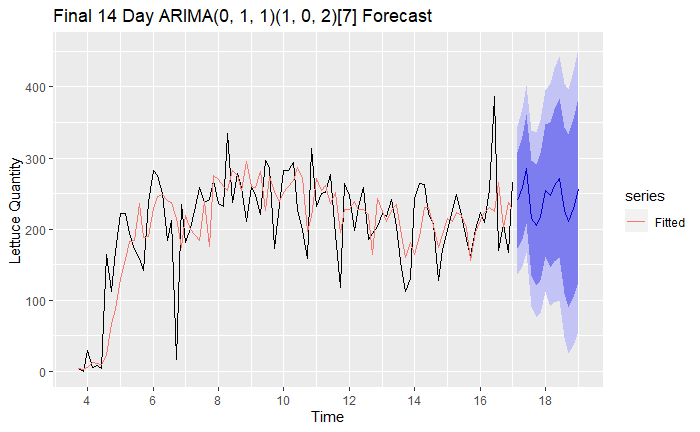

```r
autoplot(forecast_best_arima_20974,
         main = 'Final 14 Day ARIMA(0, 1, 1)(1, 0, 2)[7] Forecast',
         ylab = 'Lettuce Quantity', xlab = 'Time') +
  autolayer(fitted(forecast_best_arima_20974), series = 'Fitted', na.rm=TRUE) +
  scale_x_continuous(breaks = seq(0, 22, by = 2))
```

*Table 2.5:* *This table provides the final prediction value of time series for store 20974.* *Figure 2.4:* *This table provides the final prediction plot for store 20974.*

```
    Ljung-Box test

data:  Residuals from ARIMA(0,1,1)(1,0,2)[7]
Q* = 10.593, df = 10, p-value = 0.3901

Model df: 4.   Total lags used: 14
```

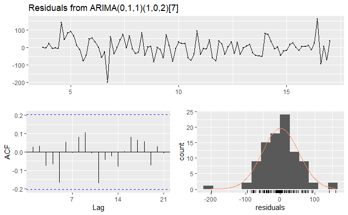

```r
checkresiduals(forecast_best_arima_20974)
```

*Figure 2.5:* *This figure provides the residual and test for store 20974.*

The four tests above indicate that the ARIMA(0, 1, 1)(1, 0, 2)[7] model is a sufficient predictive model.

### Final Forecast for Resturant 20974:

The best two selected model will be compared in this section.

```r
## Checking which model based on RMSE
accuracy_final_model_all_20974 <- rbind(forecast::accuracy(forecast_ets_20974, test_20974),
                                       forecast::accuracy(forecast_arima4_20974, test_20974))
accuracy_final_model_all_20974_df <- data.frame(accuracy_final_model_all_20974,
                                               row.names = c('Train_ets', 'Test_ets', 'Train_ts', 'Test_ts'))

accuracy_final_model_all_20974_df %>%  kable(caption = "Accuracy of Best ETS and ARIMA", align = 'c') %>%
  kable_styling(full_width = F) %>%
  pack_rows("ETS", 1, 2) %>%
  pack_rows("ARIMA(0,1,1)(1,0,2)", 3, 4)
```

[output not shown]

```r
# Best model
final_20974 <- forecast(final_ets_20974, h = 14)

autoplot(final_20974,
         main = 'Forecasted Lettuce Demand of Restaurant 20974',
         ylab = 'Lettuce Quantity',
         xlab = 'Time') +
  autolayer(fitted(final_ets_20974), series = 'Fitted', na.rm=TRUE)

#Write to csv
write.csv(final_20974, 'final_20974.csv')

## Final Forecast (Table)
final_20974_1 <- as.data.frame(forecast(final_ets_20974, h = 14))
final_store_20974_df <- data.frame(final_20974_1$`Point Forecast`,
                                 row.names = c('16/06/15', '17/06/15', '18/06/15', '19/06/15',
                                               '20/06/15', '21/06/15', '22/06/15', '23/06/15',
                                               '24/06/15', '25/06/15', '26/06/15', '27/06/15',
                                               '28/06/15', '29/06/15'))
final_store_20974_df %>%  kable(caption = "Final 14 Day ARIMA Forecast", align = 'c', col.names = 'Lettuce Demand') %>%  kable_styling(full_width = F)
```

[output not shown]